# EEB330 – Precept 04: Grammar of Graphics

Scott Wolf

Oct. 25, 2023

## [GitHub Classroom Assignment](https://classroom.github.com/a/9-0wIxZZ)

Check out the cheat sheet: [Data Visualization with ggplot2: CHEAT SHEET](https://www.maths.usyd.edu.au/u/UG/SM/STAT3022/r/current/Misc/data-visualization-2.1.pdf)

> **Reminder** If you have not installed pak, do so now. You can install it from CRAN with `install.packages("pak")` Once installed, load it with `library(pak)`.

```r
library(pak)
packages <- c("ggplot2", "cowplot", "ggthemes", "patchwork")
pak::pkg_install(packages)

lapply(packages, require, character.only = TRUE)
```

## Exercises

### Exercise 1 – Bar Plot Modification

- **Task:**
  - Add a title to the plot: “Distribution of Cars by Class”.
  - Change the x-axis label to “Type of Car”.
  - Color the bars in blue.
  - Rotate the x-axis labels by 45 degrees.
- **Expected Output:** An updated plot with the above specifications.

Initial Plot: A simple bar plot displaying the number of cars for each class in the mpg dataset.

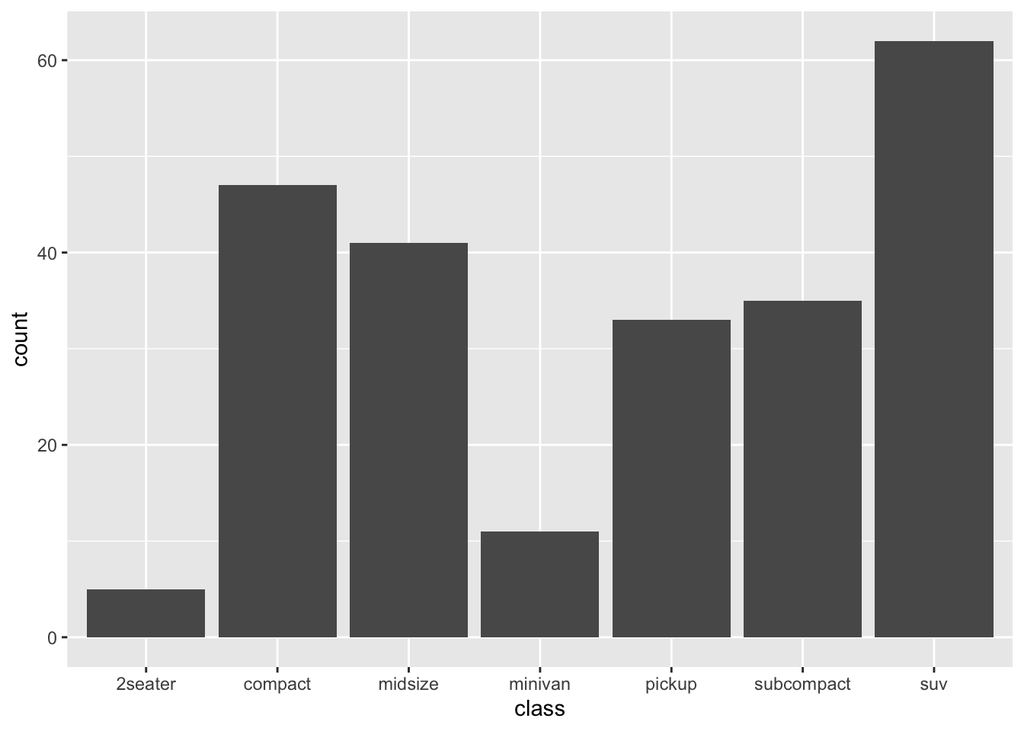

```r
ggplot(data = mpg, aes(x = class)) +
   geom_bar()
```

```r
# Your code here
```

### Exercise 2 – Histogram Modification

- **Task:**
  - Add a title to the plot: “Highway Mileage Distribution”.
  - Change the x-axis label to “Miles Per Gallon”.
  - Fill the histogram bars with green but have a black border.
  - Set the bin width to 2.
- **Expected Output:** An updated plot with the above specifications.

Initial Plot: A histogram showcasing the distribution of highway miles per gallon (hwy) from the mpg dataset.

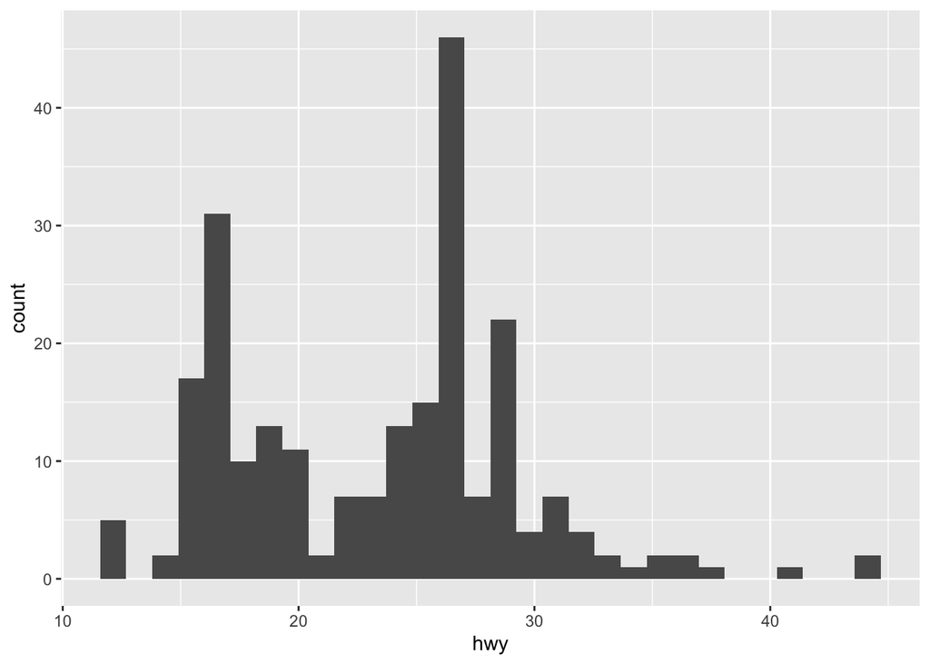

```r
ggplot(data = mpg, aes(x = hwy)) +
   geom_histogram()
```

```r
# Your code here
```

### Exercise 3 – Scatter Plot with Facets

- **Task:**
  - Add a title: “Engine Displacement vs. Highway MPG”.
  - Change the x-axis label to “Engine Size (liters)” and y-axis label to “Highway MPG”.
  - Color the points by class and shape them by the type of drive (e.g., 4wd, fwd, rwd).
  - Add a smooth trend line (with standard error) to the plot. Consider adjusting the alpha of the points for clarity.
  - Facet the plot by cyl (number of cylinders) in a 2x2 grid format.
- **Expected Output:** An updated plot with the above specifications.

Initial Plot: A scatter plot illustrating the relationship between engine displacement (displ) and highway MPG (hwy).

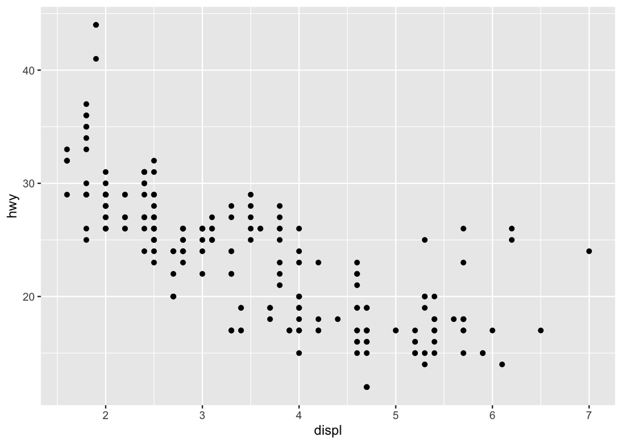

```r
ggplot(data = mpg, aes(x = displ, y = hwy)) +
  geom_point()
```

```r
# Your code here
```

### Exercise 4: Enhanced Boxplots using after_stat() and patchwork

- **Task:**
1. Modify plot1:
   - Color the boxes based on after_stat(y) (median value of cty) using a gradient from light blue (low mpg) to dark blue (high mpg).
   - Add a title: “City MPG by Manufacturer”.
   - Rotate x-axis labels by 90 degrees and adjust their size for readability.
   - Apply a theme of your choice from ggthemes.
2. Modify plot2:
   - Color the boxes based on after_stat(y) (median value of hwy) using a gradient from light green (low mpg) to dark green (high mpg).
   - Add a title: “Highway MPG by Manufacturer”.
   - Rotate x-axis labels by 90 degrees and adjust their size for readability.
   - Apply the same theme as plot1.
3. Combine the two modified plots side by side using patchwork.
- **Expected Output:** An plot with the above specifications.

```r
plot1 <- ggplot(data = mpg, aes(x = manufacturer, y = cty)) +
  geom_boxplot()

plot2 <- ggplot(data = mpg, aes(x = manufacturer, y = hwy)) +
  geom_boxplot()
```

```r
# Your code here
```